# Multilevel Modelling - Practical 5

## Instructions – start here!

**Exercise 1** allows you to analyse the ``Active Time’’ data set considered at the end of Lecture 5 of this module. If there is time remaining, you should use this to attempt/continue the formative assessment.

We initially load the packages we need.

```r
require(lme4)
require(lmerTest)
require(ggplot2)
```

## Exercise 1: Analysis of the Active Time study data (lecture 5)

Read in the data as follows.

```r
Sim3level <-
  read.csv("https://andygolightly.github.io/teaching/MATH43515/Sim3level.csv")
```

**TASK:** visually inspect the data frame. Hint: use `head()`. We have the following variables:

- `Math` maths score (response variable)
- `ActiveTime` a measure of time spent studying (covariate)
- `ClassSize` the size of a given class (covariate)
- `Classroom` Class identifier
- `School` School identifier
- `StudentID` student identifier

**TASK:** what level is each covariate measured at?

### Fit an empty three level model

We fit the random intercept only (empty model) via:

```r
Model.0 <- lmer(Math ~ 1
                 +(1|School)
                 +(1|School:Classroom),
                 data=Sim3level)
summary(Model.0)
```

```
## Linear mixed model fit by REML. t-tests use Satterthwaite's method [
## lmerModLmerTest]
## Formula: Math ~ 1 + (1 | School) + (1 | School:Classroom)
##    Data: Sim3level
##
## REML criterion at convergence: 3776.7
##
## Scaled residuals:
##     Min      1Q  Median      3Q     Max
## -3.5226 -0.6752  0.0000  0.6549  2.7502
##
## Random effects:
##  Groups           Name        Variance Std.Dev.
##  School:Classroom (Intercept) 44.93    6.703
##  School           (Intercept) 91.85    9.584
##  Residual                     37.22    6.101
## Number of obs: 570, groups:  School:Classroom, 30; School, 3
##
## Fixed effects:
##             Estimate Std. Error     df t value Pr(>|t|)
## (Intercept)   44.420      5.677  2.016   7.825   0.0156 *
## ---
## Signif. codes:  0 '***' 0.001 '**' 0.01 '*' 0.05 '.' 0.1 ' ' 1
```

We can then extract the estimated variance components from the model to calculating VPC and ICC

```r
RandomEffects <- as.data.frame(VarCorr(Model.0))
RandomEffects
```

| grp | var1 | var2 | vcov | sdcor |
| --- | --- | --- | --- | --- |
| School:Classroom | (Intercept) | NA | 44.93358 | 6.703252 |
| School | (Intercept) | NA | 91.85144 | 9.583915 |
| Residual | NA | NA | 37.21794 | 6.100651 |

(*Note*: Alternatively you could use `summary(Model.0)$varcor`.)

### VPC estimate

```r
vpc.school <-
   RandomEffects[2,4]/(RandomEffects[1,4]+RandomEffects[2,4]+RandomEffects[3,4])

vpc.class <-
  (RandomEffects[1,4])/(RandomEffects[1,4]+RandomEffects[2,4]+RandomEffects[3,4])
vpc.school
```

```
## [1] 0.5278728
```

```r
vpc.class
```

```
## [1] 0.2582346
```

### ICC estimate

```r
icc.school <-
   RandomEffects[2,4]/(RandomEffects[1,4]+RandomEffects[2,4]+RandomEffects[3,4])

icc.class <- (RandomEffects[1,4]+RandomEffects[2,4])/
   (RandomEffects[1,4]+  RandomEffects[2,4]+ RandomEffects[3,4])

icc.school
```

```
## [1] 0.5278728
```

```r
icc.class
```

```
## [1] 0.7861074
```

**TASK:** Interpet the VPC and ICC values.

### Three level Model with explanatory variables

We fit a random intercept model with covariates for `ActiveTime` and `ClassSize` with the code:

```r
Model.1 <- lmer(Math ~ ActiveTime+ClassSize
                 +(1|School)
                 +(1|School:Classroom),
                 data=Sim3level)
summary(Model.1)
```

```
## Linear mixed model fit by REML. t-tests use Satterthwaite's method [
## lmerModLmerTest]
## Formula: Math ~ ActiveTime + ClassSize + (1 | School) + (1 | School:Classroom)
##    Data: Sim3level
##
## REML criterion at convergence: 3367.1
##
## Scaled residuals:
##     Min      1Q  Median      3Q     Max
## -3.3086 -0.6518 -0.0488  0.6330  3.0744
##
## Random effects:
##  Groups           Name        Variance Std.Dev.
##  School:Classroom (Intercept) 46.55    6.823
##  School           (Intercept) 83.98    9.164
##  Residual                     17.54    4.188
## Number of obs: 570, groups:  School:Classroom, 30; School, 3
##
## Fixed effects:
##             Estimate Std. Error       df t value Pr(>|t|)
## (Intercept)  41.1849    11.9131  17.8660   3.457  0.00284 **
## ActiveTime   14.9476     0.6066 539.8898  24.643  < 2e-16 ***
## ClassSize    -0.2110     0.5634  27.9933  -0.374  0.71089
## ---
## Signif. codes:  0 '***' 0.001 '**' 0.01 '*' 0.05 '.' 0.1 ' ' 1
##
## Correlation of Fixed Effects:
##            (Intr) ActvTm
## ActiveTime -0.030
## ClassSize  -0.889  0.007
```

Note that the above can be equivalently executed via

```r
Model.1 <- lmer(Math ~ ActiveTime+ClassSize
                 +(1|School/Classroom),
                 data=Sim3level)
```

### Comparison of empty model with model with explanatory variables

```r
anova(Model.0, Model.1)
```

```
## refitting model(s) with ML (instead of REML)
```

|  | npar | AIC | BIC | logLik | deviance | Chisq | Df | Pr(>Chisq) |
| --- | --- | --- | --- | --- | --- | --- | --- | --- |
| Model.0 | 4 | 3789.815 | 3807.197 | -1890.907 | 3781.815 | NA | NA | NA |
| Model.1 | 6 | 3385.603 | 3411.677 | -1686.802 | 3373.603 | 408.2115 | 2 | 2.280289e-89 |

**TASK:** The above output suggests that explanatory variables are needed. BUT, do we need both? Look at the output of:

```r
summary(Model.1)
```

Is `ClassSize` needed?

### Further analysis (bottom up approach)

**TASK:** Perform further analysis by thinking about the following questions:

- How does the model without the `ClassSize` covariate compare to `Model.1`?
- Is a random slope needed (allow a different slope for `ActiveTime` in each class)?
- What is the final model? Is it a good fit (check diagnostics)?
- How can we visualise the fit?

### Further analysis (brief indicative solutions)

Remove `ClassSize` and refit:

```
## Linear mixed model fit by REML. t-tests use Satterthwaite's method [
## lmerModLmerTest]
## Formula: Math ~ ActiveTime + (1 | School/Classroom)
##    Data: Sim3level
##
## REML criterion at convergence: 3367.9
##
## Scaled residuals:
##     Min      1Q  Median      3Q     Max
## -3.3082 -0.6504 -0.0510  0.6339  3.0697
##
## Random effects:
##  Groups           Name        Variance Std.Dev.
##  Classroom:School (Intercept) 44.71    6.686
##  School           (Intercept) 92.65    9.626
##  Residual                     17.54    4.188
## Number of obs: 570, groups:  Classroom:School, 30; School, 3
##
## Fixed effects:
##             Estimate Std. Error       df t value Pr(>|t|)
## (Intercept)  37.2207     5.7037   2.0272   6.526   0.0219 *
## ActiveTime   14.9492     0.6065 539.9821  24.647   <2e-16 ***
## ---
## Signif. codes:  0 '***' 0.001 '**' 0.01 '*' 0.05 '.' 0.1 ' ' 1
##
## Correlation of Fixed Effects:
##            (Intr)
## ActiveTime -0.051
```

Now compare models with and without the `ClassSize` fixed effect:

```r
anova(Model.2, Model.1)
```

```
## refitting model(s) with ML (instead of REML)
```

|  | npar | AIC | BIC | logLik | deviance | Chisq | Df | Pr(>Chisq) |
| --- | --- | --- | --- | --- | --- | --- | --- | --- |
| Model.2 | 5 | 3383.882 | 3405.611 | -1686.941 | 3373.882 | NA | NA | NA |
| Model.1 | 6 | 3385.603 | 3411.677 | -1686.802 | 3373.603 | 0.278994 | 1 | 0.5973614 |

Insignificant p-value suggests that `ClassSize` can be removed as a fixed effect.

Now let’s add a random slope for `ActiveTime`:

```r
Model.3 <- lmer(Math ~ ActiveTime
                 +(1|School)
                 +(1+ActiveTime|School:Classroom),
                 data=Sim3level)
summary(Model.3)
```

```
## Linear mixed model fit by REML. t-tests use Satterthwaite's method [
## lmerModLmerTest]
## Formula: Math ~ ActiveTime + (1 | School) + (1 + ActiveTime | School:Classroom)
##    Data: Sim3level
##
## REML criterion at convergence: 3332
##
## Scaled residuals:
##      Min       1Q   Median       3Q      Max
## -3.02628 -0.64938 -0.04915  0.63336  3.03125
##
## Random effects:
##  Groups           Name        Variance Std.Dev. Corr
##  School:Classroom (Intercept)  47.64    6.902
##                   ActiveTime   24.62    4.962   -0.22
##  School           (Intercept) 100.84   10.042
##  Residual                      15.33    3.915
## Number of obs: 570, groups:  School:Classroom, 30; School, 3
##
## Fixed effects:
##             Estimate Std. Error     df t value Pr(>|t|)
## (Intercept)   37.254      5.946  1.987   6.266   0.0249 *
## ActiveTime    14.770      1.078 29.967  13.700 1.94e-14 ***
## ---
## Signif. codes:  0 '***' 0.001 '**' 0.01 '*' 0.05 '.' 0.1 ' ' 1
##
## Correlation of Fixed Effects:
##            (Intr)
## ActiveTime -0.065
```

Now test to see if the random slope variance can be assumed zero or not:

```r
ranova(Model.3)
```

|  | npar | logLik | AIC | LRT | Df | Pr(>Chisq) |
| --- | --- | --- | --- | --- | --- | --- |
|  | 7 | -1666.007 | 3346.015 | NA | NA | NA |
| (1 \| School) | 6 | -1674.685 | 3361.370 | 17.35490 | 1 | 3.100973e-05 |
| ActiveTime in (1 + ActiveTime \| School:Classroom) | 5 | -1683.971 | 3377.942 | 35.92764 | 2 | 1.579109e-08 |

Suggests that the random slope is needed.

Diagnostics:

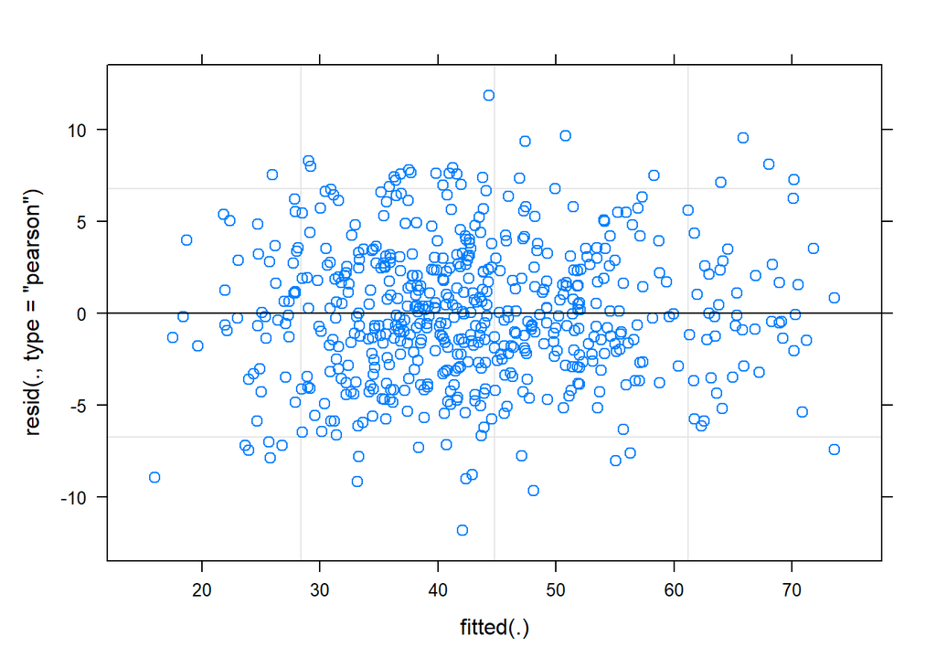

```r
plot(Model.3)
```

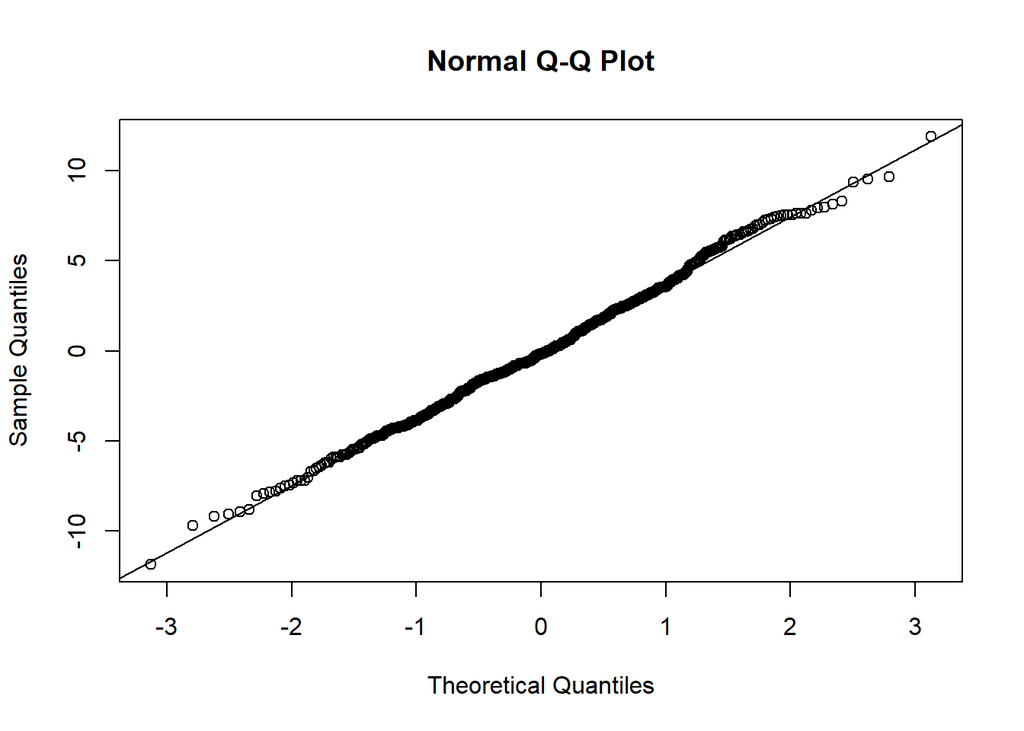

```r
qqnorm(resid(Model.3))
qqline(resid(Model.3))
```

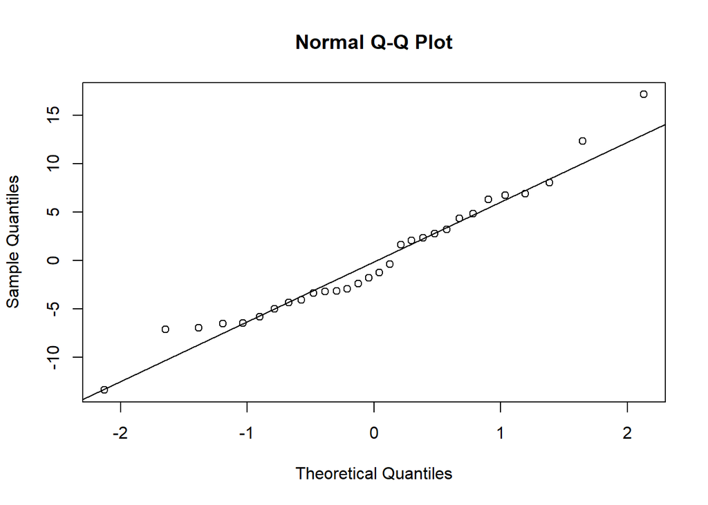

```r
qqnorm(ranef(Model.3)[[1]][,1])
qqline(ranef(Model.3)[[1]][,1])
```

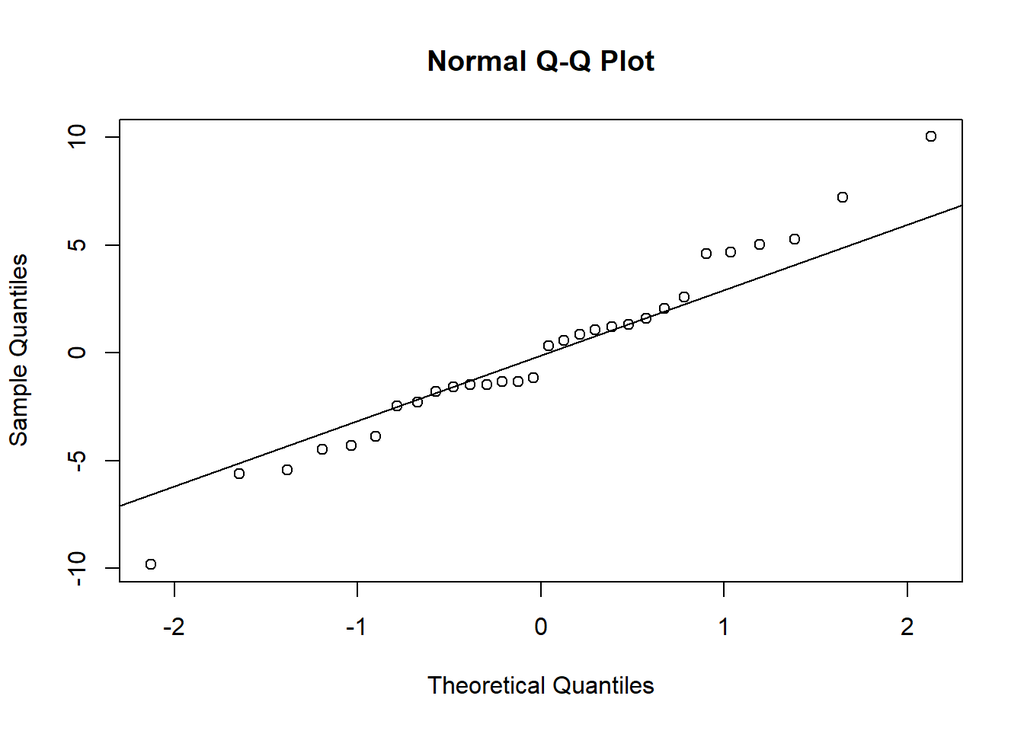

```r
qqnorm(ranef(Model.3)[[1]][,2])
qqline(ranef(Model.3)[[1]][,2])
```

Fit looks reasonable!

Visualise the fit in School 1:

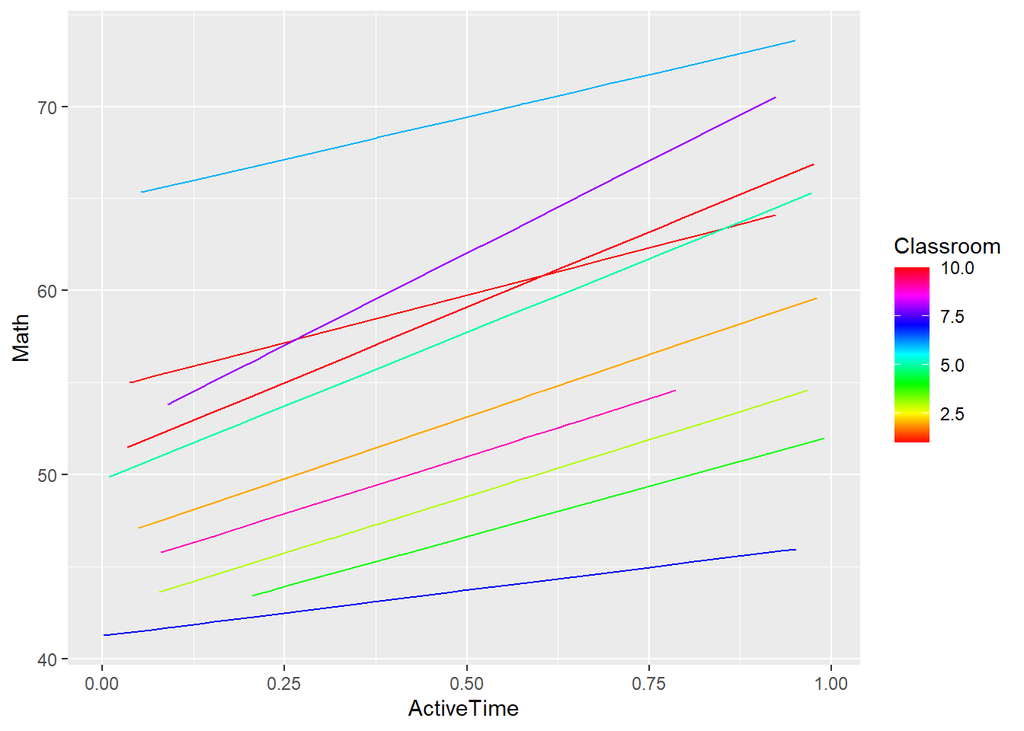

```r
Sim3level$pred <- predict(Model.3)
ggplot(Sim3level[Sim3level$School=="Sch1",],
       aes(x=ActiveTime,y=Math,col=Classroom,group=Classroom))+
  geom_line(aes(y=pred))+
  scale_color_gradientn(colours=rainbow(100))
```

## Formative assessment

If there is still time, please feel free to work on your formative assessment.